# Project: Top Expensive and Average Terraced Duplexes in Abuja

- Introduction
- Data Wrangling
- Exploratory Data Analysis
- Conclusions

## Introduction

> This project is gotten from a dataset with includes 24326 houses information in Nigeria. This data is based on Number of Bedrooms, Bathrooms, Toilets & Parking Space of each house, The title of the house, the town, state and price of the houses. Our Focus is going to be on The most Expensive Terraced Duplexes in Abuja and the Average Terraced Duplexes in Abuja. as it is discovered that there are houses in abuja which are expensive but have exactly the same properties with an average house in Abuja and they are both on developed towns in Abuja. So at the end of this project, we should be able to find out those houses in developed places that are expensive and also average in price and the numbers of bedrooms which they have.

##### Question 1 of this project is to show the location of expensive terraced duplexes in Abuja and the numbers of bedrooms available.

##### Question 2 of this project is to show the location of average terraced duplexes in Abuja, the numbers of bedrooms and the numbers of toilets available.

```python
import pandas as pd
import numpy as np
import matplotlib.pyplot as plt
import seaborn as sns
df=pd.read_csv("nigeria_houses_data.csv")
df
```

|  | bedrooms | bathrooms | toilets | parking_space | title | town | state | price |
| --- | --- | --- | --- | --- | --- | --- | --- | --- |
| 0 | 6.0 | 5.0 | 5.0 | 4.0 | Detached Duplex | Mabushi | Abuja | 450000000.0 |
| 1 | 4.0 | 5.0 | 5.0 | 4.0 | Terraced Duplexes | Katampe | Abuja | 800000000.0 |
| 2 | 4.0 | 5.0 | 5.0 | 4.0 | Detached Duplex | Lekki | Lagos | 120000000.0 |
| 3 | 4.0 | 4.0 | 5.0 | 6.0 | Detached Duplex | Ajah | Lagos | 40000000.0 |
| 4 | 4.0 | 4.0 | 5.0 | 2.0 | Semi Detached Duplex | Lekki | Lagos | 75000000.0 |
| ... | ... | ... | ... | ... | ... | ... | ... | ... |
| 24321 | 2.0 | 2.0 | 2.0 | 4.0 | Block of Flats | Kabusa | Abuja | 15000000.0 |
| 24322 | 4.0 | 5.0 | 5.0 | 4.0 | Block of Flats | Ado-Odo/Ota | Ogun | 25000000.0 |
| 24323 | 4.0 | 5.0 | 5.0 | 4.0 | Detached Duplex | Lekki | Lagos | 68000000.0 |
| 24324 | 3.0 | 4.0 | 4.0 | 3.0 | Block of Flats | Victoria Island (VI) | Lagos | 78000000.0 |
| 24325 | 4.0 | 5.0 | 5.0 | 4.0 | Detached Duplex | Lekki | Lagos | 65000000.0 |

24326 rows × 8 columns

## Data Wrangling

### General Properties

```python
df.shape
```

```
(24326, 8)
```

```python
# check for data types for each variables
df.dtypes
```

```
bedrooms         float64
bathrooms        float64
toilets          float64
parking_space    float64
title             object
town              object
state             object
price            float64
dtype: object
```

### problem with the data types of the variables

```python
# changing all object data types to category
category=["title","town","state",]
for i in category:
    df[category]=df[category].astype('category')

df.dtypes
```

```
bedrooms          float64
bathrooms         float64
toilets           float64
parking_space     float64
title            category
town             category
state            category
price             float64
dtype: object
```

```python
# changing all int data types to float
bedrooms=["bedrooms"]
for i in bedrooms:
    df[bedrooms]=df[bedrooms].astype('float')

df.dtypes
```

```
bedrooms          float64
bathrooms         float64
toilets           float64
parking_space     float64
title            category
town             category
state            category
price             float64
dtype: object
```

```python
# Check the amount of null values in the dataframe
df.isnull().sum()
```

```
bedrooms         0
bathrooms        0
toilets          0
parking_space    0
title            0
town             0
state            0
price            0
dtype: int64
```

```python
#checking for unique values
unique = df.drop('price',axis=1)
unique.columns

for r in unique.columns:
    print(r)
    print(unique[r].unique())
```

```
bedrooms
[6. 4. 5. 2. 1. 3. 8. 9. 7.]
bathrooms
[5. 4. 2. 1. 6. 3. 8. 7. 9.]
toilets
[5. 6. 3. 1. 7. 4. 8. 2. 9.]
parking_space
[4. 6. 2. 1. 5. 3. 8. 7. 9.]
title
[Detached Duplex, Terraced Duplexes, Semi Detached Duplex, Detached Bungalow, Block of Flats, Semi Detached Bungalow, Terraced Bungalow]
Categories (7, object): [Detached Duplex, Terraced Duplexes, Semi Detached Duplex, Detached Bungalow, Block of Flats, Semi Detached Bungalow, Terraced Bungalow]
town
[Mabushi, Katampe, Lekki, Ajah, Epe, ..., Ughelli North, Ibeju, Abraka, Paikoro, Ikpoba Okha]
Length: 189
Categories (189, object): [Mabushi, Katampe, Lekki, Ajah, ..., Ibeju, Abraka, Paikoro, Ikpoba Okha]
state
[Abuja, Lagos, Edo, Ogun, Oyo, ..., Kano, Katsina, Bayelsa, Borno, Niger]
Length: 25
Categories (25, object): [Abuja, Lagos, Edo, Ogun, ..., Katsina, Bayelsa, Borno, Niger]
```

```python
df.shape
```

```
(24326, 8)
```

```python
df.info()
```

```
<class 'pandas.core.frame.DataFrame'>
RangeIndex: 24326 entries, 0 to 24325
Data columns (total 8 columns):
bedrooms         24326 non-null float64
bathrooms        24326 non-null float64
toilets          24326 non-null float64
parking_space    24326 non-null float64
title            24326 non-null category
town             24326 non-null category
state            24326 non-null category
price            24326 non-null float64
dtypes: category(3), float64(5)
memory usage: 1.0 MB
```

```python
df.duplicated().sum()
```

```
10438
```

### Checking for Outliers

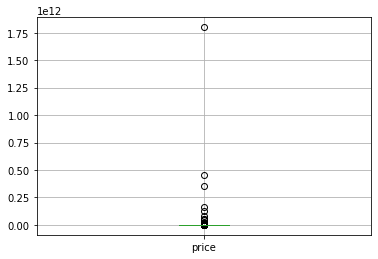

```python
#checking for outliers
df['price'].plot(kind="box").grid();
```

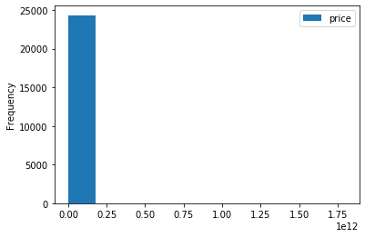

```python
df[['town','price']].plot(kind="hist");
```

### Dealing with outliers

```python
#Using inter-quartile rqnge to take out the outliners

for x in ['price']:
    q75,q25 = np.percentile(df.loc[:,x],[75,25])
    intr_qr = q75-q25


    max = q75+(1.5*intr_qr)
    min = q25-(1.5*intr_qr)

    df.loc[df[x] < min,x] = np.nan
    df.loc[df[x] > max,x] = np.nan
```

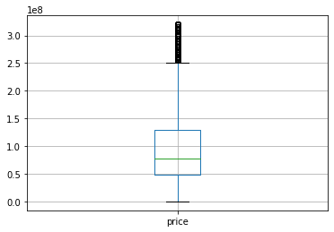

```python
df['price'].plot(kind="box").grid();
```

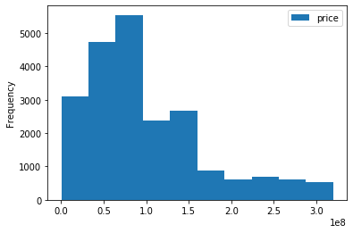

```python
df[['town','price']].plot(kind="hist");
```

```python
df
```

|  | bedrooms | bathrooms | toilets | parking_space | title | town | state | price |
| --- | --- | --- | --- | --- | --- | --- | --- | --- |
| 0 | 6.0 | 5.0 | 5.0 | 4.0 | Detached Duplex | Mabushi | Abuja | NaN |
| 1 | 4.0 | 5.0 | 5.0 | 4.0 | Terraced Duplexes | Katampe | Abuja | NaN |
| 2 | 4.0 | 5.0 | 5.0 | 4.0 | Detached Duplex | Lekki | Lagos | 120000000.0 |
| 3 | 4.0 | 4.0 | 5.0 | 6.0 | Detached Duplex | Ajah | Lagos | 40000000.0 |
| 4 | 4.0 | 4.0 | 5.0 | 2.0 | Semi Detached Duplex | Lekki | Lagos | 75000000.0 |
| ... | ... | ... | ... | ... | ... | ... | ... | ... |
| 24321 | 2.0 | 2.0 | 2.0 | 4.0 | Block of Flats | Kabusa | Abuja | 15000000.0 |
| 24322 | 4.0 | 5.0 | 5.0 | 4.0 | Block of Flats | Ado-Odo/Ota | Ogun | 25000000.0 |
| 24323 | 4.0 | 5.0 | 5.0 | 4.0 | Detached Duplex | Lekki | Lagos | 68000000.0 |
| 24324 | 3.0 | 4.0 | 4.0 | 3.0 | Block of Flats | Victoria Island (VI) | Lagos | 78000000.0 |
| 24325 | 4.0 | 5.0 | 5.0 | 4.0 | Detached Duplex | Lekki | Lagos | 65000000.0 |

24326 rows × 8 columns

### Data Cleaning (Searching and Fixing of Missing Values in the dataset)

```python
df.shape
```

```
(24326, 8)
```

```python
df.columns
```

```
Index(['bedrooms', 'bathrooms', 'toilets', 'parking_space', 'title', 'town',
       'state', 'price'],
      dtype='object')
```

#### Checking for missing values

```python
# Checking for missing values
df.isnull()
```

|  | bedrooms | bathrooms | toilets | parking_space | title | town | state | price |
| --- | --- | --- | --- | --- | --- | --- | --- | --- |
| 0 | False | False | False | False | False | False | False | True |
| 1 | False | False | False | False | False | False | False | True |
| 2 | False | False | False | False | False | False | False | False |
| 3 | False | False | False | False | False | False | False | False |
| 4 | False | False | False | False | False | False | False | False |
| ... | ... | ... | ... | ... | ... | ... | ... | ... |
| 24321 | False | False | False | False | False | False | False | False |
| 24322 | False | False | False | False | False | False | False | False |
| 24323 | False | False | False | False | False | False | False | False |
| 24324 | False | False | False | False | False | False | False | False |
| 24325 | False | False | False | False | False | False | False | False |

24326 rows × 8 columns

```python
#To generate column by column missing values
df.isnull().sum()
```

```
bedrooms            0
bathrooms           0
toilets             0
parking_space       0
title               0
town                0
state               0
price            2558
dtype: int64
```

```python
# Convert the missing value to a percentage
round((df.isnull().sum()/df.shape[0])*100, 2)
```

```
bedrooms          0.00
bathrooms         0.00
toilets           0.00
parking_space     0.00
title             0.00
town              0.00
state             0.00
price            10.52
dtype: float64
```

```python
df.isnull().sum()
```

```
bedrooms            0
bathrooms           0
toilets             0
parking_space       0
title               0
town                0
state               0
price            2558
dtype: int64
```

```python
#check for missing cases
df['price'].unique()
```

```
array([           nan, 1.20000000e+08, 4.00000000e+07, 7.50000000e+07,
       6.50000000e+07, 1.20000000e+07, 2.00000000e+08, 6.00000000e+07,
       2.50000000e+07, 4.50000000e+07, 7.00000000e+07, 4.80000000e+07,
       3.70000000e+07, 1.70000000e+08, 8.50000000e+07, 3.40000000e+07,
       1.30000000e+08, 1.60000000e+08, 2.70000000e+08, 2.50000000e+08,
       1.80000000e+08, 1.40000000e+08, 7.00000000e+06, 1.50000000e+08,
       5.50000000e+07, 3.00000000e+07, 5.30000000e+07, 2.55000000e+07,
       2.35000000e+08, 6.90000000e+07, 1.05000000e+08, 3.00000000e+08,
       4.00000000e+06, 3.60000000e+07, 5.00000000e+07, 1.10000000e+08,
       1.35000000e+08, 2.80000000e+08, 1.31000000e+08, 1.55000000e+08,
       6.90000000e+06, 1.25000000e+07, 1.00000000e+08, 2.25000000e+07,
       1.00000000e+07, 5.00000000e+06, 1.45000000e+08, 5.25000000e+07,
       6.10000000e+07, 1.50000000e+07, 2.60000000e+08, 2.98000000e+07,
       8.00000000e+07, 1.15000000e+07, 4.20000000e+07, 3.64365000e+07,
       9.00000000e+07, 4.99000000e+07, 1.30000000e+07, 2.40000000e+08,
       1.15000000e+08, 1.10000000e+07, 2.75000000e+08, 1.90000000e+08,
       2.40000000e+07, 6.00000000e+06, 3.20000000e+07, 2.00000000e+07,
       8.00000000e+06, 1.60000000e+07, 3.49000000e+07, 1.80000000e+07,
       6.80000000e+07, 3.50000000e+07, 3.30000000e+07, 3.80000000e+07,
       2.85000000e+07, 2.10000000e+07, 7.40000000e+07, 9.00000000e+06,
       3.00000000e+06, 1.25000000e+08, 4.70000000e+07, 9.50000000e+07,
       2.20000000e+07, 1.65000000e+08, 6.09000000e+07, 8.20000000e+07,
       3.10000000e+07, 1.85000000e+08, 3.85000000e+07, 5.20000000e+07,
       6.70000000e+07, 3.60000000e+06, 6.20000000e+07, 2.60000000e+07,
       4.30000000e+07, 1.55000000e+07, 7.20000000e+07, 4.60000000e+07,
       1.95000000e+08, 5.80000000e+07, 3.90000000e+07, 7.70000000e+07,
       2.30000000e+08, 1.98000000e+08, 6.50000000e+06, 2.30000000e+07,
       1.70000000e+07, 2.70000000e+07, 4.90000000e+07, 1.06000000e+08,
       4.50000000e+06, 8.70000000e+07, 2.90000000e+08, 1.62500000e+07,
       9.80000000e+07, 5.90000000e+07, 5.70000000e+07, 2.80000000e+07,
       6.30000000e+07, 1.75000000e+08, 1.81198248e+08, 1.95000000e+07,
       6.29900000e+07, 3.65000000e+07, 3.15000000e+08, 1.82000000e+08,
       7.80000000e+07, 1.35000000e+07, 3.20000000e+08, 7.10000000e+07,
       1.40000000e+07, 2.10000000e+08, 2.99999999e+08, 2.69900000e+07,
       7.60000000e+07, 2.20000000e+08, 1.05000000e+07, 6.08000000e+07,
       2.65000000e+07, 2.82500000e+07, 3.20000009e+08, 1.75000000e+06,
       8.50000000e+06, 9.40000000e+07, 2.65000000e+08, 4.10000000e+07,
       5.40000000e+07, 1.12500000e+08, 2.90000000e+07, 1.90000000e+07,
       5.10000000e+07, 9.10000000e+07, 1.22000000e+08, 8.95000000e+07,
       2.85000000e+08, 8.30000000e+07, 7.85000000e+07, 8.10000000e+06,
```

[output cut: 48 more lines]

```
       7.24799950e+07, 3.35000000e+06, 1.52000000e+08, 9.31875000e+07,
       7.40250000e+07, 9.83647490e+07, 1.59000000e+08, 2.58000000e+08,
       3.09000000e+07, 3.20000000e+06, 3.80000000e+06, 3.91365000e+07,
       8.45500000e+06, 1.93000000e+08, 1.37000000e+07, 4.95000000e+07,
       1.16000000e+08, 7.49900000e+06, 1.99900000e+08, 1.49999999e+08,
       3.55000000e+07, 6.30000000e+06, 1.65666666e+08, 1.51200000e+07,
       3.59000000e+07, 6.05000000e+07, 1.63200000e+07, 1.00000000e+05,
       1.76020999e+08, 1.64000000e+08, 1.15000005e+08, 4.72500000e+07,
       1.37200000e+07, 6.25000000e+07, 1.04990000e+07, 4.89900000e+07,
       1.40000000e+06, 3.49999990e+07, 5.22500000e+07, 1.84900000e+08,
       2.38000000e+08, 2.99500000e+07, 2.23000000e+07, 9.85000000e+07,
       2.70000900e+06, 2.59000000e+07, 8.08500000e+07, 2.02000000e+07,
       1.81000000e+08, 2.22075000e+07, 1.78000000e+07, 5.88000000e+07,
       2.32000000e+08, 4.35000000e+07, 4.85865000e+07, 1.78750000e+07,
       3.98000000e+07, 7.00000000e+05])
```

```python
#look for the highest occurence to fix the missing values
df.groupby('price')['price'].count()
```

```
price
90000.0          1
100000.0         1
110000.0         1
350000.0         3
400000.0         1
              ...
305000000.0      2
310000000.0     49
315000000.0      6
320000000.0    116
320000009.0      1
Name: price, Length: 409, dtype: int64
```

```python
# using the mean to fix the missing values in price column

df['price'] = df['price'].fillna(df['price'].mean())
```

```python
df.isnull()
```

|  | bedrooms | bathrooms | toilets | parking_space | title | town | state | price |
| --- | --- | --- | --- | --- | --- | --- | --- | --- |
| 0 | False | False | False | False | False | False | False | False |
| 1 | False | False | False | False | False | False | False | False |
| 2 | False | False | False | False | False | False | False | False |
| 3 | False | False | False | False | False | False | False | False |
| 4 | False | False | False | False | False | False | False | False |
| ... | ... | ... | ... | ... | ... | ... | ... | ... |
| 24321 | False | False | False | False | False | False | False | False |
| 24322 | False | False | False | False | False | False | False | False |
| 24323 | False | False | False | False | False | False | False | False |
| 24324 | False | False | False | False | False | False | False | False |
| 24325 | False | False | False | False | False | False | False | False |

24326 rows × 8 columns

```python
df.isnull().sum()
```

```
bedrooms         0
bathrooms        0
toilets          0
parking_space    0
title            0
town             0
state            0
price            0
dtype: int64
```

```python
# Convert the missing value to a percentage
round((df.isnull().sum()/df.shape[0])*100, 2)
```

```
bedrooms         0.0
bathrooms        0.0
toilets          0.0
parking_space    0.0
title            0.0
town             0.0
state            0.0
price            0.0
dtype: float64
```

#### The missing values have been fixed

```python
# Price of Terraced Duplexes in Abuja and the number of bedrooms
df2=df[['town','state', 'title','bedrooms','toilets','bathrooms','parking_space','price']].loc[(df['state']=='Abuja') & (df['title']=='Terraced Duplexes')].reset_index()
df2
```

|  | index | town | state | title | bedrooms | toilets | bathrooms | parking_space | price |
| --- | --- | --- | --- | --- | --- | --- | --- | --- | --- |
| 0 | 1 | Katampe | Abuja | Terraced Duplexes | 4.0 | 5.0 | 5.0 | 4.0 | 9.872252e+07 |
| 1 | 10 | Lokogoma District | Abuja | Terraced Duplexes | 3.0 | 5.0 | 4.0 | 4.0 | 2.500000e+07 |
| 2 | 75 | Katampe | Abuja | Terraced Duplexes | 4.0 | 6.0 | 5.0 | 4.0 | 1.310000e+08 |
| 3 | 84 | Kaura | Abuja | Terraced Duplexes | 5.0 | 6.0 | 5.0 | 2.0 | 7.000000e+07 |
| 4 | 85 | Jahi | Abuja | Terraced Duplexes | 4.0 | 5.0 | 5.0 | 4.0 | 7.500000e+07 |
| ... | ... | ... | ... | ... | ... | ... | ... | ... | ... |
| 1045 | 24177 | Karmo | Abuja | Terraced Duplexes | 4.0 | 5.0 | 5.0 | 4.0 | 4.000000e+07 |
| 1046 | 24206 | Life Camp | Abuja | Terraced Duplexes | 4.0 | 5.0 | 4.0 | 2.0 | 6.000000e+07 |
| 1047 | 24254 | Life Camp | Abuja | Terraced Duplexes | 4.0 | 5.0 | 5.0 | 4.0 | 7.500000e+07 |
| 1048 | 24256 | Katampe | Abuja | Terraced Duplexes | 4.0 | 5.0 | 5.0 | 3.0 | 7.500000e+07 |
| 1049 | 24282 | Mbora (Nbora) | Abuja | Terraced Duplexes | 4.0 | 5.0 | 4.0 | 4.0 | 4.500000e+07 |

1050 rows × 9 columns

```python
df2.describe()
```

|  | index | bedrooms | toilets | bathrooms | parking_space | price |
| --- | --- | --- | --- | --- | --- | --- |
| count | 1050.000000 | 1050.000000 | 1050.000000 | 1050.000000 | 1050.000000 | 1.050000e+03 |
| mean | 12396.928571 | 4.002857 | 5.043810 | 4.414286 | 3.649524 | 7.731679e+07 |
| std | 7076.414934 | 0.677144 | 0.752489 | 0.846000 | 1.105073 | 4.526273e+07 |
| min | 1.000000 | 1.000000 | 1.000000 | 1.000000 | 1.000000 | 3.000000e+06 |
| 25% | 6425.750000 | 4.000000 | 5.000000 | 4.000000 | 3.000000 | 5.000000e+07 |
| 50% | 12626.500000 | 4.000000 | 5.000000 | 4.000000 | 4.000000 | 6.500000e+07 |
| 75% | 18567.750000 | 4.000000 | 5.000000 | 5.000000 | 4.000000 | 9.000000e+07 |
| max | 24282.000000 | 7.000000 | 8.000000 | 9.000000 | 9.000000 | 3.000000e+08 |

```python
# Checking for Duplicates
df2.duplicated().sum()
```

```
0
```

#### this shows that data for abuja has no duplicate

```python
df2.info()
```

```
<class 'pandas.core.frame.DataFrame'>
RangeIndex: 1050 entries, 0 to 1049
Data columns (total 9 columns):
index            1050 non-null int64
town             1050 non-null category
state            1050 non-null category
title            1050 non-null category
bedrooms         1050 non-null float64
toilets          1050 non-null float64
bathrooms        1050 non-null float64
parking_space    1050 non-null float64
price            1050 non-null float64
dtypes: category(3), float64(5), int64(1)
memory usage: 57.8 KB
```

```python
df2.shape
```

```
(1050, 9)
```

```python
# Checking for unique data#checking for unique values
unique = df2.drop(['index','price'],axis=1)
unique.columns

for r in unique.columns:
    print(r)
    print(unique[r].unique())
```

```
town
[Katampe, Lokogoma District, Kaura, Jahi, Guzape District, ..., Garki, Gwagwalada, Kurudu, Kukwaba, Karu]
Length: 39
Categories (39, object): [Katampe, Lokogoma District, Kaura, Jahi, ..., Gwagwalada, Kurudu, Kukwaba, Karu]
state
[Abuja]
Categories (1, object): [Abuja]
title
[Terraced Duplexes]
Categories (1, object): [Terraced Duplexes]
bedrooms
[4. 3. 5. 2. 6. 1. 7.]
toilets
[5. 6. 3. 4. 7. 1. 8. 2.]
bathrooms
[5. 4. 3. 6. 2. 7. 1. 9. 8.]
parking_space
[4. 2. 3. 9. 5. 1. 6. 8. 7.]
```

```python
df2
```

|  | index | town | state | title | bedrooms | toilets | bathrooms | parking_space | price |
| --- | --- | --- | --- | --- | --- | --- | --- | --- | --- |
| 0 | 1 | Katampe | Abuja | Terraced Duplexes | 4.0 | 5.0 | 5.0 | 4.0 | 9.872252e+07 |
| 1 | 10 | Lokogoma District | Abuja | Terraced Duplexes | 3.0 | 5.0 | 4.0 | 4.0 | 2.500000e+07 |
| 2 | 75 | Katampe | Abuja | Terraced Duplexes | 4.0 | 6.0 | 5.0 | 4.0 | 1.310000e+08 |
| 3 | 84 | Kaura | Abuja | Terraced Duplexes | 5.0 | 6.0 | 5.0 | 2.0 | 7.000000e+07 |
| 4 | 85 | Jahi | Abuja | Terraced Duplexes | 4.0 | 5.0 | 5.0 | 4.0 | 7.500000e+07 |
| ... | ... | ... | ... | ... | ... | ... | ... | ... | ... |
| 1045 | 24177 | Karmo | Abuja | Terraced Duplexes | 4.0 | 5.0 | 5.0 | 4.0 | 4.000000e+07 |
| 1046 | 24206 | Life Camp | Abuja | Terraced Duplexes | 4.0 | 5.0 | 4.0 | 2.0 | 6.000000e+07 |
| 1047 | 24254 | Life Camp | Abuja | Terraced Duplexes | 4.0 | 5.0 | 5.0 | 4.0 | 7.500000e+07 |
| 1048 | 24256 | Katampe | Abuja | Terraced Duplexes | 4.0 | 5.0 | 5.0 | 3.0 | 7.500000e+07 |
| 1049 | 24282 | Mbora (Nbora) | Abuja | Terraced Duplexes | 4.0 | 5.0 | 4.0 | 4.0 | 4.500000e+07 |

1050 rows × 9 columns

```python
# record of town, bedroom and price in abuja group by town
df3=df2[['town','bedrooms','price', 'toilets']].groupby('town').sum().reset_index()
df3
```

|  | town | bedrooms | price | toilets |
| --- | --- | --- | --- | --- |
| 0 | Aba | 0.0 | 0.000000e+00 | 0.0 |
| 1 | Abeokuta North | 0.0 | 0.000000e+00 | 0.0 |
| 2 | Abeokuta South | 0.0 | 0.000000e+00 | 0.0 |
| 3 | Abraka | 0.0 | 0.000000e+00 | 0.0 |
| 4 | Ado-Ekiti | 0.0 | 0.000000e+00 | 0.0 |
| ... | ... | ... | ... | ... |
| 184 | Wuse 2 | 128.0 | 5.468723e+09 | 156.0 |
| 185 | Wuye | 392.0 | 6.448723e+09 | 491.0 |
| 186 | Yaba | 0.0 | 0.000000e+00 | 0.0 |
| 187 | Yenagoa | 0.0 | 0.000000e+00 | 0.0 |
| 188 | Yewa South | 0.0 | 0.000000e+00 | 0.0 |

189 rows × 4 columns

```python
# Bedrooms, price and towns in abuja
abj=df3[['town','bedrooms','price']].loc[(df3['price']!=0) & (df3['bedrooms']!=0)].reset_index()
abj
```

|  | index | town | bedrooms | price |
| --- | --- | --- | --- | --- |
| 0 | 17 | Apo | 111.0 | 1.530445e+09 |
| 1 | 20 | Asokoro District | 44.0 | 1.085613e+09 |
| 2 | 28 | Dakwo | 4.0 | 3.200000e+07 |
| 3 | 30 | Dape | 15.0 | 1.620000e+08 |
| 4 | 33 | Diplomatic Zones | 7.0 | 1.200000e+08 |
| 5 | 35 | Durumi | 68.0 | 1.227890e+09 |
| 6 | 49 | Gaduwa | 72.0 | 7.650000e+08 |
| 7 | 50 | Galadimawa | 97.0 | 9.559500e+08 |
| 8 | 51 | Garki | 11.0 | 2.350000e+08 |
| 9 | 53 | Gudu | 31.0 | 4.900000e+08 |
| 10 | 55 | Guzape District | 607.0 | 1.312685e+10 |
| 11 | 56 | Gwagwalada | 2.0 | 1.200000e+07 |
| 12 | 57 | Gwarinpa | 157.0 | 2.947722e+09 |
| 13 | 69 | Idu Industrial | 20.0 | 2.409000e+08 |
| 14 | 93 | Jabi | 200.0 | 5.700823e+09 |
| 15 | 94 | Jahi | 335.0 | 5.697500e+09 |
| 16 | 99 | Kabusa | 9.0 | 1.050000e+08 |
| 17 | 100 | Kado | 28.0 | 8.250000e+08 |
| 18 | 104 | Kagini | 6.0 | 4.100000e+07 |
| 19 | 106 | Karmo | 77.0 | 9.180000e+08 |
| 20 | 107 | Karsana | 45.0 | 3.888000e+08 |
| 21 | 109 | Karu | 2.0 | 1.500000e+07 |
| 22 | 110 | Katampe | 396.0 | 8.135298e+09 |
| 23 | 111 | Kaura | 75.0 | 1.157400e+09 |
| 24 | 115 | Kubwa | 72.0 | 7.372990e+08 |
| 25 | 116 | Kuje | 13.0 | 4.300000e+07 |
| 26 | 117 | Kukwaba | 4.0 | 1.000000e+08 |
| 27 | 118 | Kurudu | 3.0 | 2.500000e+07 |
| 28 | 123 | Life Camp | 694.0 | 1.011826e+10 |
| 29 | 124 | Lokogoma District | 58.0 | 6.320000e+08 |
| 30 | 126 | Lugbe District | 49.0 | 7.480000e+08 |
| 31 | 127 | Mabushi | 129.0 | 3.005000e+09 |
| 32 | 130 | Maitama District | 125.0 | 5.320447e+09 |
| 33 | 133 | Mbora (Nbora) | 23.0 | 3.480000e+08 |
| 34 | 177 | Utako | 66.0 | 1.528000e+09 |
| 35 | 182 | Wumba | 4.0 | 5.000000e+07 |
| 36 | 183 | Wuse | 24.0 | 6.950000e+08 |
| 37 | 184 | Wuse 2 | 128.0 | 5.468723e+09 |
| 38 | 185 | Wuye | 392.0 | 6.448723e+09 |

```python
abj.describe().drop('index',axis=1)
```

|  | bedrooms | price |
| --- | --- | --- |
| count | 39.000000 | 3.900000e+01 |
| mean | 107.769231 | 2.081606e+09 |
| std | 162.179962 | 3.115210e+09 |
| min | 2.000000 | 1.200000e+07 |
| 25% | 12.000000 | 1.410000e+08 |
| 50% | 49.000000 | 7.480000e+08 |
| 75% | 118.000000 | 2.239083e+09 |
| max | 694.000000 | 1.312685e+10 |

```python
high=abj.loc[abj['price'] <= np.percentile(abj['price'],75)]
high.sort_values(by='price', ascending = False)
```

|  | index | town | bedrooms | price |
| --- | --- | --- | --- | --- |
| 0 | 17 | Apo | 111.0 | 1.530445e+09 |
| 34 | 177 | Utako | 66.0 | 1.528000e+09 |
| 5 | 35 | Durumi | 68.0 | 1.227890e+09 |
| 23 | 111 | Kaura | 75.0 | 1.157400e+09 |
| 1 | 20 | Asokoro District | 44.0 | 1.085613e+09 |
| 7 | 50 | Galadimawa | 97.0 | 9.559500e+08 |
| 19 | 106 | Karmo | 77.0 | 9.180000e+08 |
| 17 | 100 | Kado | 28.0 | 8.250000e+08 |
| 6 | 49 | Gaduwa | 72.0 | 7.650000e+08 |
| 30 | 126 | Lugbe District | 49.0 | 7.480000e+08 |
| 24 | 115 | Kubwa | 72.0 | 7.372990e+08 |
| 36 | 183 | Wuse | 24.0 | 6.950000e+08 |
| 29 | 124 | Lokogoma District | 58.0 | 6.320000e+08 |
| 9 | 53 | Gudu | 31.0 | 4.900000e+08 |
| 20 | 107 | Karsana | 45.0 | 3.888000e+08 |
| 33 | 133 | Mbora (Nbora) | 23.0 | 3.480000e+08 |
| 13 | 69 | Idu Industrial | 20.0 | 2.409000e+08 |
| 8 | 51 | Garki | 11.0 | 2.350000e+08 |
| 3 | 30 | Dape | 15.0 | 1.620000e+08 |
| 4 | 33 | Diplomatic Zones | 7.0 | 1.200000e+08 |
| 16 | 99 | Kabusa | 9.0 | 1.050000e+08 |
| 26 | 117 | Kukwaba | 4.0 | 1.000000e+08 |
| 35 | 182 | Wumba | 4.0 | 5.000000e+07 |
| 25 | 116 | Kuje | 13.0 | 4.300000e+07 |
| 18 | 104 | Kagini | 6.0 | 4.100000e+07 |
| 2 | 28 | Dakwo | 4.0 | 3.200000e+07 |
| 27 | 118 | Kurudu | 3.0 | 2.500000e+07 |
| 21 | 109 | Karu | 2.0 | 1.500000e+07 |
| 11 | 56 | Gwagwalada | 2.0 | 1.200000e+07 |

```python
high.describe().drop('index',axis=1)
```

|  | bedrooms | price |
| --- | --- | --- |
| count | 29.000000 | 2.900000e+01 |
| mean | 35.862069 | 5.245964e+08 |
| std | 32.214376 | 4.790381e+08 |
| min | 2.000000 | 1.200000e+07 |
| 25% | 7.000000 | 1.000000e+08 |
| 50% | 24.000000 | 3.888000e+08 |
| 75% | 66.000000 | 8.250000e+08 |
| max | 111.000000 | 1.530445e+09 |

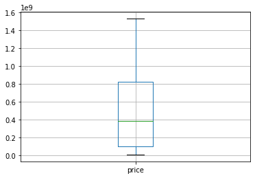

```python
high['price'].plot(kind='box').grid()
```

```python
high.isnull()
```

|  | index | town | bedrooms | price |
| --- | --- | --- | --- | --- |
| 0 | False | False | False | False |
| 1 | False | False | False | False |
| 2 | False | False | False | False |
| 3 | False | False | False | False |
| 4 | False | False | False | False |
| 5 | False | False | False | False |
| 6 | False | False | False | False |
| 7 | False | False | False | False |
| 8 | False | False | False | False |
| 9 | False | False | False | False |
| 11 | False | False | False | False |
| 13 | False | False | False | False |
| 16 | False | False | False | False |
| 17 | False | False | False | False |
| 18 | False | False | False | False |
| 19 | False | False | False | False |
| 20 | False | False | False | False |
| 21 | False | False | False | False |
| 23 | False | False | False | False |
| 24 | False | False | False | False |
| 25 | False | False | False | False |
| 26 | False | False | False | False |
| 27 | False | False | False | False |
| 29 | False | False | False | False |
| 30 | False | False | False | False |
| 33 | False | False | False | False |
| 34 | False | False | False | False |
| 35 | False | False | False | False |
| 36 | False | False | False | False |

```python
high.isnull().sum()
```

```
index       0
town        0
bedrooms    0
price       0
dtype: int64
```

```python
high.info()
```

```
<class 'pandas.core.frame.DataFrame'>
Int64Index: 29 entries, 0 to 36
Data columns (total 4 columns):
index       29 non-null int64
town        29 non-null category
bedrooms    29 non-null float64
price       29 non-null float64
dtypes: category(1), float64(2), int64(1)
memory usage: 4.7 KB
```

##### There are no missing values found in Terraced Duplexes in Abuja data set.

```python
high
```

|  | index | town | bedrooms | price |
| --- | --- | --- | --- | --- |
| 0 | 17 | Apo | 111.0 | 1.530445e+09 |
| 1 | 20 | Asokoro District | 44.0 | 1.085613e+09 |
| 2 | 28 | Dakwo | 4.0 | 3.200000e+07 |
| 3 | 30 | Dape | 15.0 | 1.620000e+08 |
| 4 | 33 | Diplomatic Zones | 7.0 | 1.200000e+08 |
| 5 | 35 | Durumi | 68.0 | 1.227890e+09 |
| 6 | 49 | Gaduwa | 72.0 | 7.650000e+08 |
| 7 | 50 | Galadimawa | 97.0 | 9.559500e+08 |
| 8 | 51 | Garki | 11.0 | 2.350000e+08 |
| 9 | 53 | Gudu | 31.0 | 4.900000e+08 |
| 11 | 56 | Gwagwalada | 2.0 | 1.200000e+07 |
| 13 | 69 | Idu Industrial | 20.0 | 2.409000e+08 |
| 16 | 99 | Kabusa | 9.0 | 1.050000e+08 |
| 17 | 100 | Kado | 28.0 | 8.250000e+08 |
| 18 | 104 | Kagini | 6.0 | 4.100000e+07 |
| 19 | 106 | Karmo | 77.0 | 9.180000e+08 |
| 20 | 107 | Karsana | 45.0 | 3.888000e+08 |
| 21 | 109 | Karu | 2.0 | 1.500000e+07 |
| 23 | 111 | Kaura | 75.0 | 1.157400e+09 |
| 24 | 115 | Kubwa | 72.0 | 7.372990e+08 |
| 25 | 116 | Kuje | 13.0 | 4.300000e+07 |
| 26 | 117 | Kukwaba | 4.0 | 1.000000e+08 |
| 27 | 118 | Kurudu | 3.0 | 2.500000e+07 |
| 29 | 124 | Lokogoma District | 58.0 | 6.320000e+08 |
| 30 | 126 | Lugbe District | 49.0 | 7.480000e+08 |
| 33 | 133 | Mbora (Nbora) | 23.0 | 3.480000e+08 |
| 34 | 177 | Utako | 66.0 | 1.528000e+09 |
| 35 | 182 | Wumba | 4.0 | 5.000000e+07 |
| 36 | 183 | Wuse | 24.0 | 6.950000e+08 |

#### The data set is okay and ready for exploration

## Exploratory Data Analysis

### Research Question 1 (Show the location of the Top 15 Terraced Duplexes according to their prices and the total number of bedrooms in Abuja)

```python
#15 Most expensive Terraced Duplexes in Abuja in Descending order and their numbers of bedrooms
high2= high.sort_values(by = 'price', ascending = False).head(15)
high2
```

|  | index | town | bedrooms | price |
| --- | --- | --- | --- | --- |
| 0 | 17 | Apo | 111.0 | 1.530445e+09 |
| 34 | 177 | Utako | 66.0 | 1.528000e+09 |
| 5 | 35 | Durumi | 68.0 | 1.227890e+09 |
| 23 | 111 | Kaura | 75.0 | 1.157400e+09 |
| 1 | 20 | Asokoro District | 44.0 | 1.085613e+09 |
| 7 | 50 | Galadimawa | 97.0 | 9.559500e+08 |
| 19 | 106 | Karmo | 77.0 | 9.180000e+08 |
| 17 | 100 | Kado | 28.0 | 8.250000e+08 |
| 6 | 49 | Gaduwa | 72.0 | 7.650000e+08 |
| 30 | 126 | Lugbe District | 49.0 | 7.480000e+08 |
| 24 | 115 | Kubwa | 72.0 | 7.372990e+08 |
| 36 | 183 | Wuse | 24.0 | 6.950000e+08 |
| 29 | 124 | Lokogoma District | 58.0 | 6.320000e+08 |
| 9 | 53 | Gudu | 31.0 | 4.900000e+08 |
| 20 | 107 | Karsana | 45.0 | 3.888000e+08 |

```python
# Info of the 15 most expensive terraced duplexes in abuja
# high = high.drop('index', axis=1)
high2.info()
```

```
<class 'pandas.core.frame.DataFrame'>
Int64Index: 15 entries, 0 to 20
Data columns (total 4 columns):
index       15 non-null int64
town        15 non-null category
bedrooms    15 non-null float64
price       15 non-null float64
dtypes: category(1), float64(2), int64(1)
memory usage: 4.2 KB
```

#### Percentage of Price by Town

```python
# Function to find percentage between two columns grouped by one column

def percent(dframe, column1, column2):
    percentage = 'percentage'
    p = round(dframe.groupby(column1)[column2].sum(), 2).to_frame()
    p[percentage] = round((p[column2]/dframe[column2].sum())*100, 2)
    p[percentage] = p[percentage].apply(lambda x: str(x)+ '%')
    return p
```

```python
percent(high2, 'town', 'price').sort_values(by='price', ascending = False).head(15)
```

| town | price | percentage |
| --- | --- | --- |
| Apo | 1.530445e+09 | 11.18% |
| Utako | 1.528000e+09 | 11.17% |
| Durumi | 1.227890e+09 | 8.97% |
| Kaura | 1.157400e+09 | 8.46% |
| Asokoro District | 1.085613e+09 | 7.93% |
| Galadimawa | 9.559500e+08 | 6.99% |
| Karmo | 9.180000e+08 | 6.71% |
| Kado | 8.250000e+08 | 6.03% |
| Gaduwa | 7.650000e+08 | 5.59% |
| Lugbe District | 7.480000e+08 | 5.47% |
| Kubwa | 7.372990e+08 | 5.39% |
| Wuse | 6.950000e+08 | 5.08% |
| Lokogoma District | 6.320000e+08 | 4.62% |
| Gudu | 4.900000e+08 | 3.58% |
| Karsana | 3.888000e+08 | 2.84% |

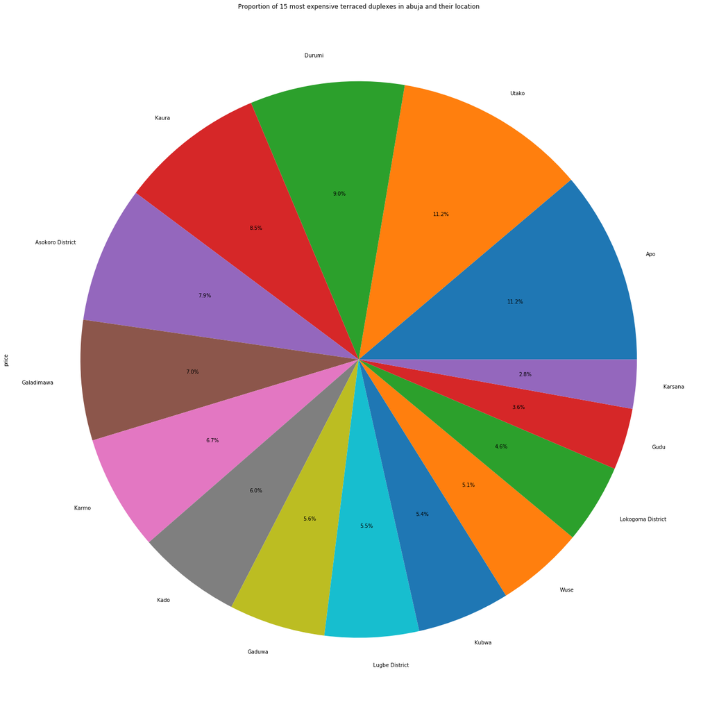

```python
# chart to show the percentage of the 15 most expensive terraced duplexes and their location in Abuja
high2['price'].plot(kind='pie', autopct='%1.1f%%',labels=high2.town, title='Proportion of 15 most expensive terraced duplexes in abuja and their location', figsize=[25,25]);
```

```python
#15 Most expensive terraced duplexes in Abuja in Descending order and their numbers of bedrooms
high3=high.sort_values(by = 'bedrooms', ascending = False).head(15)
high3
```

|  | index | town | bedrooms | price |
| --- | --- | --- | --- | --- |
| 0 | 17 | Apo | 111.0 | 1.530445e+09 |
| 7 | 50 | Galadimawa | 97.0 | 9.559500e+08 |
| 19 | 106 | Karmo | 77.0 | 9.180000e+08 |
| 23 | 111 | Kaura | 75.0 | 1.157400e+09 |
| 6 | 49 | Gaduwa | 72.0 | 7.650000e+08 |
| 24 | 115 | Kubwa | 72.0 | 7.372990e+08 |
| 5 | 35 | Durumi | 68.0 | 1.227890e+09 |
| 34 | 177 | Utako | 66.0 | 1.528000e+09 |
| 29 | 124 | Lokogoma District | 58.0 | 6.320000e+08 |
| 30 | 126 | Lugbe District | 49.0 | 7.480000e+08 |
| 20 | 107 | Karsana | 45.0 | 3.888000e+08 |
| 1 | 20 | Asokoro District | 44.0 | 1.085613e+09 |
| 9 | 53 | Gudu | 31.0 | 4.900000e+08 |
| 17 | 100 | Kado | 28.0 | 8.250000e+08 |
| 36 | 183 | Wuse | 24.0 | 6.950000e+08 |

#### Percentage of bedrooms by town

```python
percent(high3, 'town', 'bedrooms').sort_values(by='bedrooms', ascending = False).head(15)
```

| town | bedrooms | percentage |
| --- | --- | --- |
| Apo | 111.0 | 12.1% |
| Galadimawa | 97.0 | 10.58% |
| Karmo | 77.0 | 8.4% |
| Kaura | 75.0 | 8.18% |
| Gaduwa | 72.0 | 7.85% |
| Kubwa | 72.0 | 7.85% |
| Durumi | 68.0 | 7.42% |
| Utako | 66.0 | 7.2% |
| Lokogoma District | 58.0 | 6.32% |
| Lugbe District | 49.0 | 5.34% |
| Karsana | 45.0 | 4.91% |
| Asokoro District | 44.0 | 4.8% |
| Gudu | 31.0 | 3.38% |
| Kado | 28.0 | 3.05% |
| Wuse | 24.0 | 2.62% |

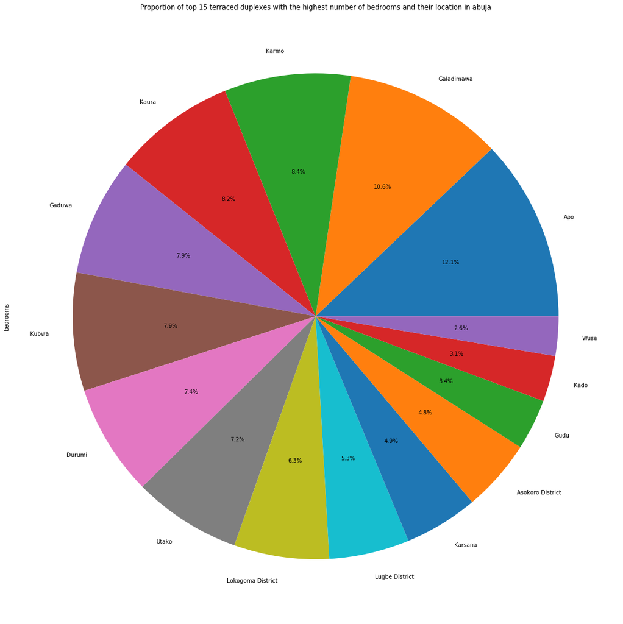

```python
high3['bedrooms'].plot(kind='pie', autopct='%1.1f%%',labels=high3.town, title='Proportion of top 15 terraced duplexes with the highest number of bedrooms and their location in abuja', figsize=[20,20]);
```

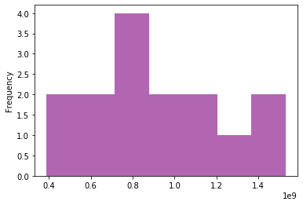

```python
# histogram showing the 15 most expensive terraced duplexes in abuja
high2['price'].plot(kind='hist',bins=7, alpha=0.6,color="purple")
```

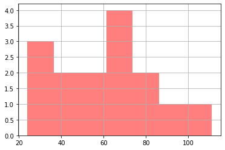

```python
# histogram showing the top 15 terraced duplexes in abuja with the highest number of bedrooms
high3['bedrooms'].hist(bins=7, alpha=0.5,color="red");
```

```python
high3['bedrooms']
```

```
0     111.0
7      97.0
19     77.0
23     75.0
6      72.0
24     72.0
5      68.0
34     66.0
29     58.0
30     49.0
20     45.0
1      44.0
9      31.0
17     28.0
36     24.0
Name: bedrooms, dtype: float64
```

```python
high2['price']
```

```
0     1.530445e+09
34    1.528000e+09
5     1.227890e+09
23    1.157400e+09
1     1.085613e+09
7     9.559500e+08
19    9.180000e+08
17    8.250000e+08
6     7.650000e+08
30    7.480000e+08
24    7.372990e+08
36    6.950000e+08
29    6.320000e+08
9     4.900000e+08
20    3.888000e+08
Name: price, dtype: float64
```

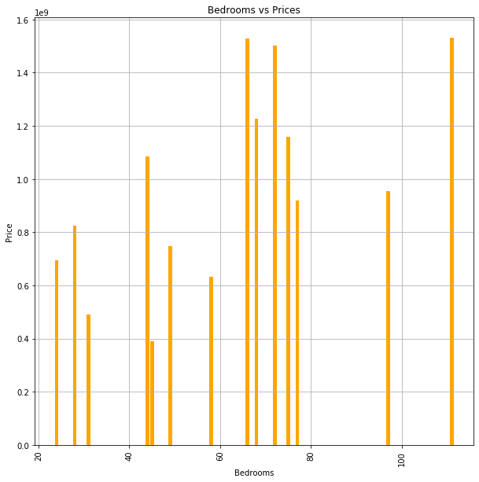

```python
# Chart to visualize the top 15 bedrooms and their prices of terraced duplexes in Abuja
plt.figure(figsize=(10,10))
plt.title('Bedrooms vs Prices')
y = high2.groupby('bedrooms')['price'].sum().values
x = high3.groupby('bedrooms')['price'].sum().index
plt.xlabel('Bedrooms')
plt.ylabel('Price')
plt.xticks(rotation=90)
plt.bar(x,y, color='orange')
plt.grid()
plt.show()
```

```python
high2.groupby('town')[['price']].mean().sort_values(by='price',ascending=False).head(15)
```

| town | price |
| --- | --- |
| Apo | 1.530445e+09 |
| Utako | 1.528000e+09 |
| Durumi | 1.227890e+09 |
| Kaura | 1.157400e+09 |
| Asokoro District | 1.085613e+09 |
| Galadimawa | 9.559500e+08 |
| Karmo | 9.180000e+08 |
| Kado | 8.250000e+08 |
| Gaduwa | 7.650000e+08 |
| Lugbe District | 7.480000e+08 |
| Kubwa | 7.372990e+08 |
| Wuse | 6.950000e+08 |
| Lokogoma District | 6.320000e+08 |
| Gudu | 4.900000e+08 |
| Karsana | 3.888000e+08 |

### Research Question 2 (Show the location of Average terraced duplexes in Abuja with their numbers of bedrooms and toilets)

```python
df3.info()
```

```
<class 'pandas.core.frame.DataFrame'>
RangeIndex: 189 entries, 0 to 188
Data columns (total 4 columns):
town        189 non-null category
bedrooms    189 non-null float64
price       189 non-null float64
toilets     189 non-null float64
dtypes: category(1), float64(3)
memory usage: 8.6 KB
```

```python
# Bedrooms,Toilet, price and towns in abuja
abj2=df3[['town','bedrooms','toilets','price']].loc[(df3['price']!=0) & (df3['bedrooms']!=0) & (df3['toilets'] !=0)].reset_index()
abj2
```

|  | index | town | bedrooms | toilets | price |
| --- | --- | --- | --- | --- | --- |
| 0 | 17 | Apo | 111.0 | 142.0 | 1.530445e+09 |
| 1 | 20 | Asokoro District | 44.0 | 57.0 | 1.085613e+09 |
| 2 | 28 | Dakwo | 4.0 | 5.0 | 3.200000e+07 |
| 3 | 30 | Dape | 15.0 | 17.0 | 1.620000e+08 |
| 4 | 33 | Diplomatic Zones | 7.0 | 9.0 | 1.200000e+08 |
| 5 | 35 | Durumi | 68.0 | 87.0 | 1.227890e+09 |
| 6 | 49 | Gaduwa | 72.0 | 87.0 | 7.650000e+08 |
| 7 | 50 | Galadimawa | 97.0 | 123.0 | 9.559500e+08 |
| 8 | 51 | Garki | 11.0 | 15.0 | 2.350000e+08 |
| 9 | 53 | Gudu | 31.0 | 41.0 | 4.900000e+08 |
| 10 | 55 | Guzape District | 607.0 | 754.0 | 1.312685e+10 |
| 11 | 56 | Gwagwalada | 2.0 | 5.0 | 1.200000e+07 |
| 12 | 57 | Gwarinpa | 157.0 | 203.0 | 2.947722e+09 |
| 13 | 69 | Idu Industrial | 20.0 | 25.0 | 2.409000e+08 |
| 14 | 93 | Jabi | 200.0 | 251.0 | 5.700823e+09 |
| 15 | 94 | Jahi | 335.0 | 424.0 | 5.697500e+09 |
| 16 | 99 | Kabusa | 9.0 | 14.0 | 1.050000e+08 |
| 17 | 100 | Kado | 28.0 | 33.0 | 8.250000e+08 |
| 18 | 104 | Kagini | 6.0 | 8.0 | 4.100000e+07 |
| 19 | 106 | Karmo | 77.0 | 97.0 | 9.180000e+08 |
| 20 | 107 | Karsana | 45.0 | 57.0 | 3.888000e+08 |
| 21 | 109 | Karu | 2.0 | 3.0 | 1.500000e+07 |
| 22 | 110 | Katampe | 396.0 | 502.0 | 8.135298e+09 |
| 23 | 111 | Kaura | 75.0 | 95.0 | 1.157400e+09 |
| 24 | 115 | Kubwa | 72.0 | 95.0 | 7.372990e+08 |
| 25 | 116 | Kuje | 13.0 | 17.0 | 4.300000e+07 |
| 26 | 117 | Kukwaba | 4.0 | 5.0 | 1.000000e+08 |
| 27 | 118 | Kurudu | 3.0 | 4.0 | 2.500000e+07 |
| 28 | 123 | Life Camp | 694.0 | 866.0 | 1.011826e+10 |
| 29 | 124 | Lokogoma District | 58.0 | 74.0 | 6.320000e+08 |
| 30 | 126 | Lugbe District | 49.0 | 65.0 | 7.480000e+08 |
| 31 | 127 | Mabushi | 129.0 | 163.0 | 3.005000e+09 |
| 32 | 130 | Maitama District | 125.0 | 157.0 | 5.320447e+09 |
| 33 | 133 | Mbora (Nbora) | 23.0 | 30.0 | 3.480000e+08 |
| 34 | 177 | Utako | 66.0 | 84.0 | 1.528000e+09 |
| 35 | 182 | Wumba | 4.0 | 5.0 | 5.000000e+07 |
| 36 | 183 | Wuse | 24.0 | 30.0 | 6.950000e+08 |
| 37 | 184 | Wuse 2 | 128.0 | 156.0 | 5.468723e+09 |
| 38 | 185 | Wuye | 392.0 | 491.0 | 6.448723e+09 |

```python
# Average terraced duplexes in Abuja in Descending Order
ave=abj2.loc[abj2['price'] <= np.percentile(abj2['price'],50)]
ave.sort_values(by='price', ascending = False)
```

|  | index | town | bedrooms | toilets | price |
| --- | --- | --- | --- | --- | --- |
| 30 | 126 | Lugbe District | 49.0 | 65.0 | 748000000.0 |
| 24 | 115 | Kubwa | 72.0 | 95.0 | 737299000.0 |
| 36 | 183 | Wuse | 24.0 | 30.0 | 695000000.0 |
| 29 | 124 | Lokogoma District | 58.0 | 74.0 | 632000000.0 |
| 9 | 53 | Gudu | 31.0 | 41.0 | 490000000.0 |
| 20 | 107 | Karsana | 45.0 | 57.0 | 388800000.0 |
| 33 | 133 | Mbora (Nbora) | 23.0 | 30.0 | 348000000.0 |
| 13 | 69 | Idu Industrial | 20.0 | 25.0 | 240900000.0 |
| 8 | 51 | Garki | 11.0 | 15.0 | 235000000.0 |
| 3 | 30 | Dape | 15.0 | 17.0 | 162000000.0 |
| 4 | 33 | Diplomatic Zones | 7.0 | 9.0 | 120000000.0 |
| 16 | 99 | Kabusa | 9.0 | 14.0 | 105000000.0 |
| 26 | 117 | Kukwaba | 4.0 | 5.0 | 100000000.0 |
| 35 | 182 | Wumba | 4.0 | 5.0 | 50000000.0 |
| 25 | 116 | Kuje | 13.0 | 17.0 | 43000000.0 |
| 18 | 104 | Kagini | 6.0 | 8.0 | 41000000.0 |
| 2 | 28 | Dakwo | 4.0 | 5.0 | 32000000.0 |
| 27 | 118 | Kurudu | 3.0 | 4.0 | 25000000.0 |
| 21 | 109 | Karu | 2.0 | 3.0 | 15000000.0 |
| 11 | 56 | Gwagwalada | 2.0 | 5.0 | 12000000.0 |

```python
ave_price=ave.sort_values(by='price', ascending=False).head(10)
ave_price
```

|  | index | town | bedrooms | toilets | price |
| --- | --- | --- | --- | --- | --- |
| 30 | 126 | Lugbe District | 49.0 | 65.0 | 748000000.0 |
| 24 | 115 | Kubwa | 72.0 | 95.0 | 737299000.0 |
| 36 | 183 | Wuse | 24.0 | 30.0 | 695000000.0 |
| 29 | 124 | Lokogoma District | 58.0 | 74.0 | 632000000.0 |
| 9 | 53 | Gudu | 31.0 | 41.0 | 490000000.0 |
| 20 | 107 | Karsana | 45.0 | 57.0 | 388800000.0 |
| 33 | 133 | Mbora (Nbora) | 23.0 | 30.0 | 348000000.0 |
| 13 | 69 | Idu Industrial | 20.0 | 25.0 | 240900000.0 |
| 8 | 51 | Garki | 11.0 | 15.0 | 235000000.0 |
| 3 | 30 | Dape | 15.0 | 17.0 | 162000000.0 |

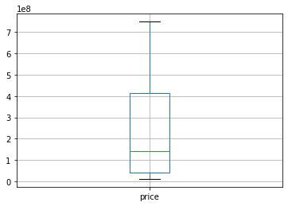

```python
ave['price'].plot(kind='box').grid()
```

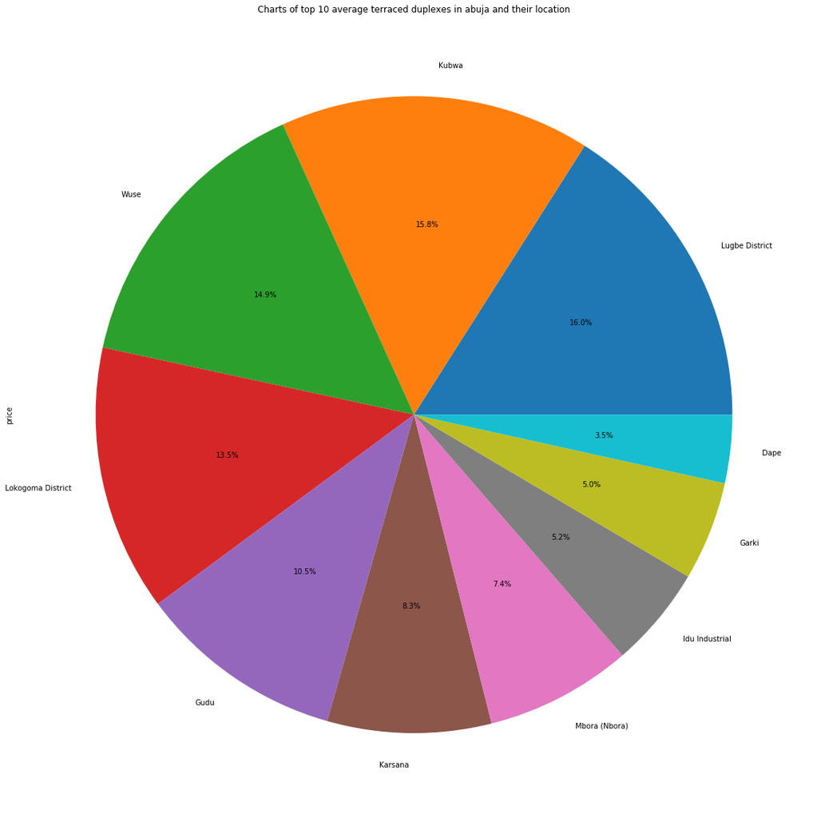

```python
# chart to show the percentage of top 10 Average terraced duplexes and their location in Abuja
ave_price['price'].plot(kind='pie', autopct='%1.1f%%',labels=ave_price.town, title='Charts of top 10 average terraced duplexes in abuja and their location', figsize=[20,20]);
```

##### The highest average terraced duplexes in Abuja is located at Lugbe District and the 10th Average terraced duplexes in Abuja is located at Dape

```python
ave_bedroom=ave.sort_values(by='bedrooms', ascending=False).head(10)
ave_bedroom
```

|  | index | town | bedrooms | toilets | price |
| --- | --- | --- | --- | --- | --- |
| 24 | 115 | Kubwa | 72.0 | 95.0 | 737299000.0 |
| 29 | 124 | Lokogoma District | 58.0 | 74.0 | 632000000.0 |
| 30 | 126 | Lugbe District | 49.0 | 65.0 | 748000000.0 |
| 20 | 107 | Karsana | 45.0 | 57.0 | 388800000.0 |
| 9 | 53 | Gudu | 31.0 | 41.0 | 490000000.0 |
| 36 | 183 | Wuse | 24.0 | 30.0 | 695000000.0 |
| 33 | 133 | Mbora (Nbora) | 23.0 | 30.0 | 348000000.0 |
| 13 | 69 | Idu Industrial | 20.0 | 25.0 | 240900000.0 |
| 3 | 30 | Dape | 15.0 | 17.0 | 162000000.0 |
| 25 | 116 | Kuje | 13.0 | 17.0 | 43000000.0 |

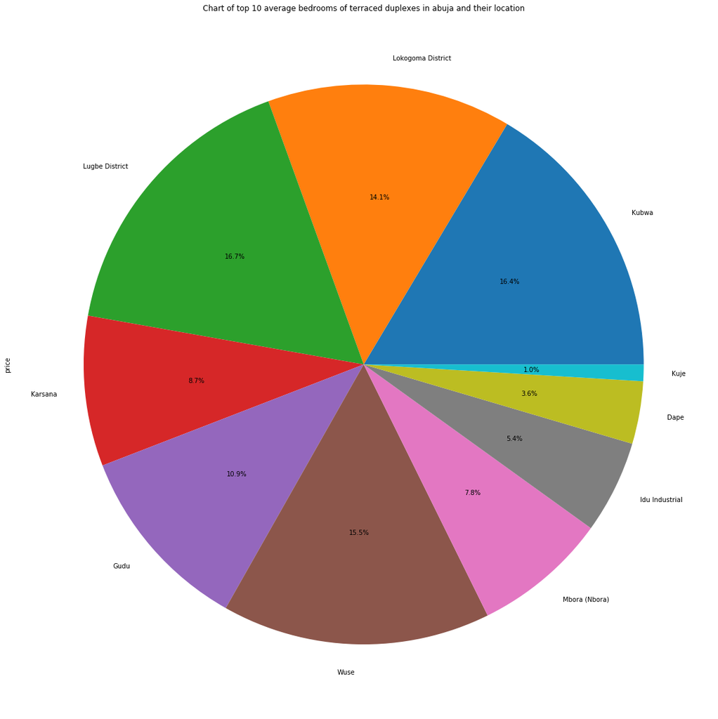

```python
# chart to show the percentage of top 10 Average bedrooms and their location of terraced duplexes in Abuja
ave_bedroom['price'].plot(kind='pie', autopct='%1.1f%%',labels=ave_bedroom.town, title='Chart of top 10 average bedrooms of terraced duplexes in abuja and their location', figsize=[20,20]);
```

```python
ave_toilet=ave.sort_values(by='toilets', ascending=False).head(10)
ave_toilet
```

|  | index | town | bedrooms | toilets | price |
| --- | --- | --- | --- | --- | --- |
| 24 | 115 | Kubwa | 72.0 | 95.0 | 737299000.0 |
| 29 | 124 | Lokogoma District | 58.0 | 74.0 | 632000000.0 |
| 30 | 126 | Lugbe District | 49.0 | 65.0 | 748000000.0 |
| 20 | 107 | Karsana | 45.0 | 57.0 | 388800000.0 |
| 9 | 53 | Gudu | 31.0 | 41.0 | 490000000.0 |
| 36 | 183 | Wuse | 24.0 | 30.0 | 695000000.0 |
| 33 | 133 | Mbora (Nbora) | 23.0 | 30.0 | 348000000.0 |
| 13 | 69 | Idu Industrial | 20.0 | 25.0 | 240900000.0 |
| 3 | 30 | Dape | 15.0 | 17.0 | 162000000.0 |
| 25 | 116 | Kuje | 13.0 | 17.0 | 43000000.0 |

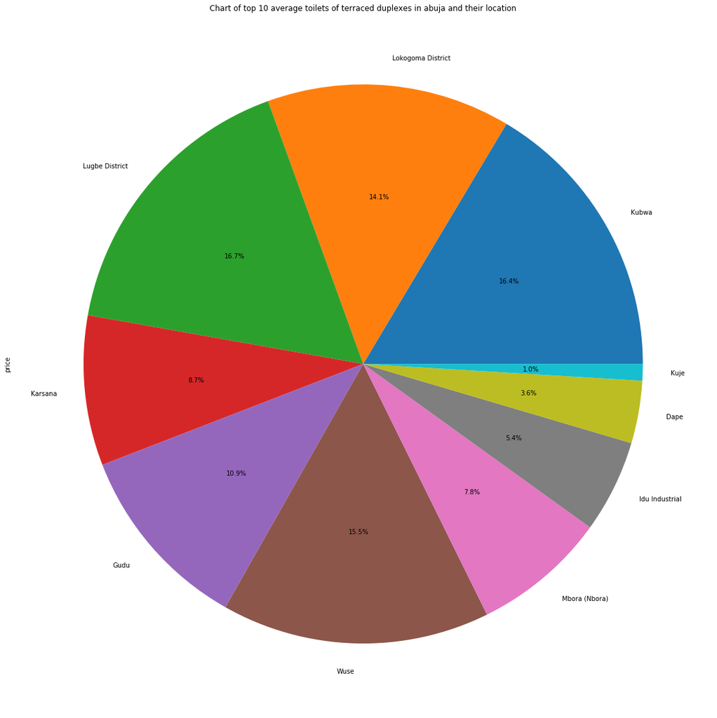

```python
# chart to show the percentage of top 10 Average toilets of terraced duplexes and their location in Abuja
ave_toilet['price'].plot(kind='pie', autopct='%1.1f%%',labels=ave_toilet.town, title='Chart of top 10 average toilets of terraced duplexes in abuja and their location', figsize=[20,20]);
```

#### For clients who wants more toilets in an average terraced duplex building, it can be gotten at Kubwa

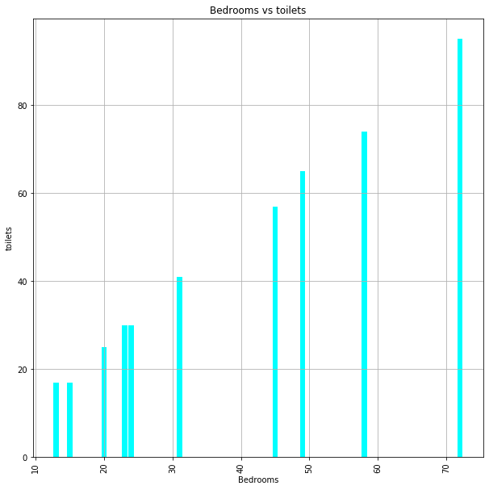

```python
# Chart to visualize the top 15 bedrooms and their prices of terraced duplexes in Abuja
plt.figure(figsize=(10,10))
plt.title('Bedrooms vs toilets')
y = ave_toilet.groupby('bedrooms')['toilets'].sum().values
x = ave_bedroom.groupby('bedrooms')['toilets'].sum().index
plt.xlabel('Bedrooms')
plt.ylabel('toilets')
plt.xticks(rotation=90)
plt.bar(x,y, color='aqua')
plt.grid()
plt.show()
```

## Conclusions

##### This shows that not all terraced duplexes in the develped parts of are really that expensive.

#### It is also discovered that bedrooms of terraced duplexes in Kubwa are actually more in an apartment compare to wuse.

#### In general, the developed towns of Abuja do not only have terraced duplexes at higher cost, they also have average terraced duplexes at average prices which is what most clients want. so it is advisable to do proper survey of where those average terraced duplexes can be found within these towns.